# Analyzing Data Science Job Descriptions

### Examining Our Results

Now that we have our parsed descriptions and company information, let's see what patterns emerge when looking holistically at all of the jobs we scraped.

(The files we are going to examine come from three separate 2500 job runs of the Job Web Scraping.ipynb notebook on 10/31, 11/2, and 11/4)

```python
# import our packages
import pandas as pd
import numpy as np
import seaborn as sns
import matplotlib.pyplot as plt
from matplotlib.ticker import FuncFormatter
import re
```

```python
import warnings
warnings.filterwarnings('ignore')
```

```python
# import our output files from the web scraping
output = pd.read_csv('output-2500-2019-10-31.csv', index_col = 0)
output2 = pd.read_csv('output-2500-2019-11-02.csv', index_col = 0)
output3 = pd.read_csv('output-2500-2019-11-04.csv', index_col = 0)
```

```python
# combine the two different files and check how many rows we have
output = output.append(output2, ignore_index = True).drop_duplicates(keep = 'last')
output = output.append(output3, ignore_index = True).drop_duplicates(keep = 'last')
output.shape
```

```
(2871, 73)
```

In total, we have 2871 unique jobs that we can examine. Let's just see what the most common job titles were to make sure we actually have relevant results (at least in name only)

```python
# show the 10 most common job titles
titles = pd.DataFrame(round(output['job title'].value_counts() / output.shape[0] * 100, 2))
titles = titles.head(10)
titles.index.names = ['Job Title']
titles.columns = ['Frequency (%)']
titles
```

| Job Title | Frequency (%) |
| --- | --- |
| Data Scientist | 34.80 |
| Senior Data Scientist | 3.41 |
| Associate Data Scientist | 1.36 |
| Lead Data Scientist | 1.04 |
| Data Science Intern | 0.94 |
| Sr. Data Scientist | 0.84 |
| DATA SCIENTIST | 0.80 |
| Junior Data Scientist | 0.73 |
| Data Scientist II | 0.52 |
| Data Scientist I | 0.45 |

#### Good news!

Indeed.com seems to be providing relevant results when searching for data scientist jobs, as most of the titles are for a data scientist role (in some capacity and with varying levels of seniority).

Now lets learn more about where these jobs are located and what industry domain we would be working in:

```python
## plot number of jobs by state ##

# create a data frame with state and number of jobs columns
states = pd.DataFrame(output['state'].value_counts())
states.index.name = 'state'
states.columns = ['count']
states.reset_index(inplace = True)


# plotly code adapted from https://plot.ly/python/choropleth-maps/
import plotly.graph_objects as go

# create figure
fig = go.Figure(data=go.Choropleth(
    locations=states['state'], # geographic locations
    z = states['count'].astype(float), # Data to be color-coded
    locationmode = 'USA-states', # set of locations
    colorscale = 'Blues',
    colorbar_title = "Number of Jobs",
))

fig.update_layout(
    title_text = 'Number of Data Science Jobs by State',
    geo_scope='usa', # limit map scope to USA
)

fig.show()
```

[interactive chart not shown]

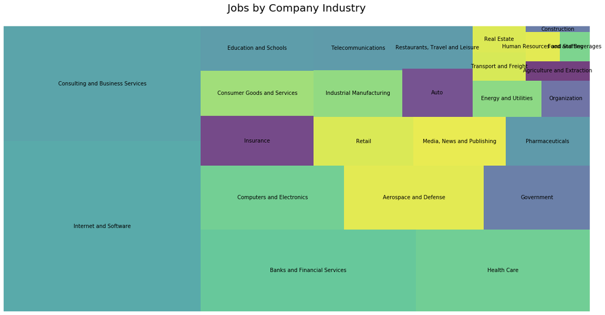

```python
# plot industry using squarify tree plot
import squarify

# create our data frame
industry = pd.DataFrame(output['Industry'].value_counts())
industry.index.name = 'industry'
industry.columns = ['count']
industry.reset_index(inplace = True)

# create plot using squarify
plt.figure(figsize = (20,10))
squarify.plot(sizes=industry['count'], label=industry['industry'], alpha=.75)
plt.axis('off')
plt.title("Jobs by Company Industry\n",fontsize=20)
plt.show()
```

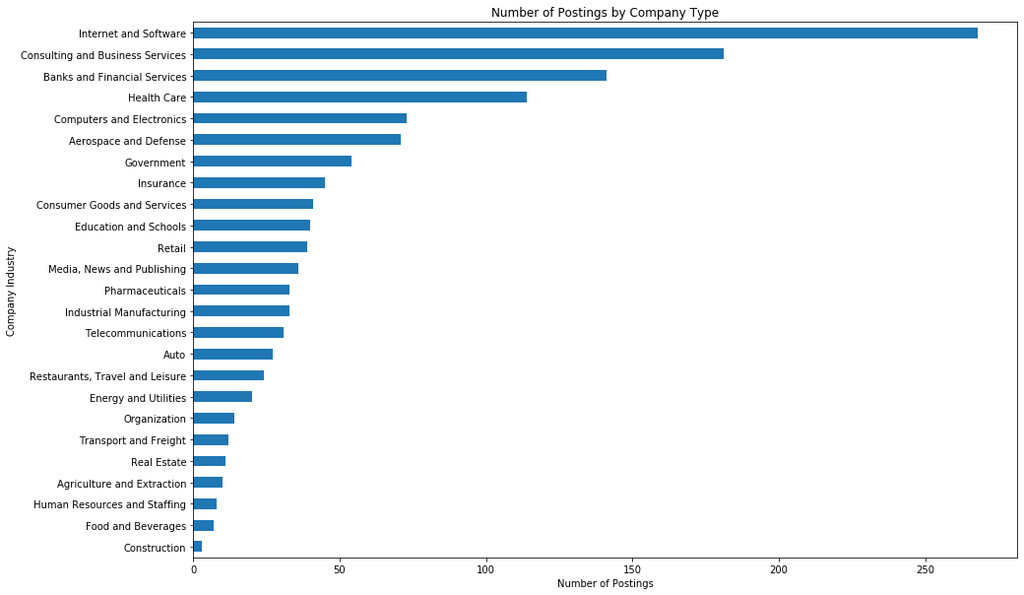

```python
output['Industry'].value_counts().sort_values(ascending = True).plot(kind = 'barh', figsize = (15,10))
plt.title('Number of Postings by Company Type')
plt.ylabel('Company Industry')
plt.xlabel('Number of Postings')
plt.show()
```

```python
# determine some of the most common industry-state pairs within the data
stateIndustry = pd.DataFrame(output.groupby(['state', 'Industry'])['job'].agg('count'))
stateIndustry.sort_values(by = 'job', ascending = False).head(15)
```

| state | Industry | job |
| --- | --- | --- |
| WA | Internet and Software | 68 |
| CA | Internet and Software | 62 |
| VA | Consulting and Business Services | 59 |
| CA | Computers and Electronics | 41 |
| NY | Internet and Software | 38 |
| DC | Consulting and Business Services | 33 |
| VA | Aerospace and Defense | 26 |
| NY | Banks and Financial Services | 26 |
| VA | Banks and Financial Services | 24 |
| MA | Internet and Software | 19 |
| CA | Health Care | 16 |
|  | Banks and Financial Services | 15 |
| VA | Internet and Software | 12 |
| NY | Media, News and Publishing | 12 |
|  | Insurance | 11 |

So most of the companies are some form of Software, Consulting, or Financial Services companies. But are they primarily start-ups, or established companies?

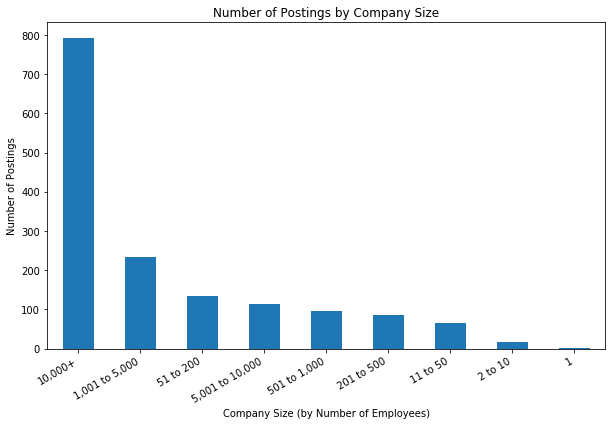

```python
# company information by number of employees
output['Employees size'].value_counts().plot(kind = 'bar', figsize = (10,6))
plt.title('Number of Postings by Company Size')
plt.xticks(rotation = 30, ha = 'right')
plt.xlabel('Company Size (by Number of Employees)')
plt.ylabel('Number of Postings')
plt.show()
```

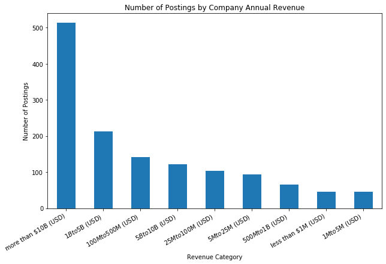

```python
plt.figure(figsize = (10,6))
output['Revenue'].value_counts().plot(kind = 'bar', figsize = (10,6))
plt.title('Number of Postings by Company Annual Revenue')
plt.xticks(rotation = 30, ha = 'right')
plt.xlabel('Revenue Category')
plt.ylabel('Number of Postings')
plt.show()
```

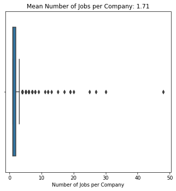

```python
# lets find the average number of jobs by company
a = pd.DataFrame(output.groupby('company')['job'].count())
plt.figure(figsize = (6,6))
f = sns.boxplot(a.job)
f.set_xlabel('Number of Jobs per Company')
f.set_title('Mean Number of Jobs per Company: ' + str(np.mean(a.job).round(2)))
```

```python
# Find the companies posting the most jobs
a = pd.DataFrame(output.groupby(['company'])['job'].count().sort_values(ascending = False))
print('Number of companies with more than one job: '+ str(a[a.job > 1]['job'].count()))
print()
print('Top 15 Companies by Number of Postings')
a.rename(columns = {'job':'Number of Posted Jobs'}).head(15)
```

```
Number of companies with more than one job: 451

Top 15 Companies by Number of Postings
```

| company | Number of Posted Jobs |
| --- | --- |
| Apple | 48 |
| Amazon.com Services, Inc. | 30 |
| Facebook | 27 |
| Booz Allen Hamilton | 25 |
| Microsoft | 20 |
| Capital One - US | 19 |
| IBM | 19 |
| Google | 17 |
| Deloitte | 15 |
| Bank of America | 13 |
| Walmart | 12 |
| SAIC | 12 |
| AETNA | 11 |
| Spotify | 9 |
| JP Morgan Chase | 8 |

So most of these companies are large and established, with Apple, Amazon, Facebook, Booz Allen, and Microsot rounding out the top 5 most prolific employers. This would make sense if we are looking at all jobs across the US. Large companies like these might have more money to advertize their positions, and more resources to reach out to potential employers wherever they may be.

#### Now let's look at the job descriptions themselves

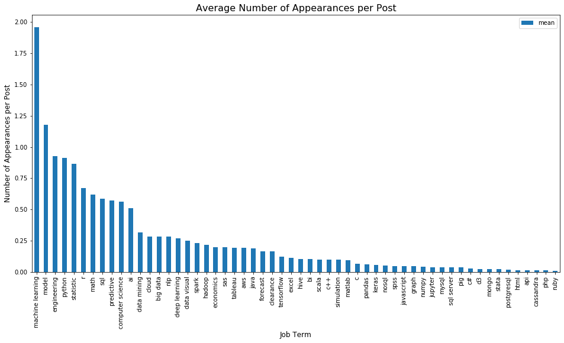

```python
# number of appearances of each term within each post
temp = output.loc[:,:'clearance']
temp2 = pd.DataFrame(np.mean(temp), index = temp.columns.values, columns = ['mean'])
temp2 = temp2.sort_values(by = 'mean', ascending = False)
temp2[(temp2['mean'] > 0.01)].plot(kind = 'bar', figsize = (16,8))
plt.title('Average Number of Appearances per Post', fontsize = 16)
plt.xlabel('Job Term', fontsize = 12)
plt.ylabel('Number of Appearances per Post', fontsize = 12)
plt.show()
```

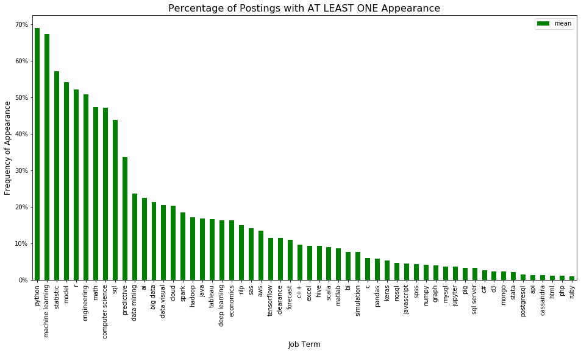

```python
# frequency of appearance within each post
temp2 = pd.DataFrame(np.mean(temp > 0), index = temp.columns.values, columns = ['mean'])
temp2 = temp2.sort_values(by = 'mean', ascending = False)
a = temp2[(temp2['mean'] > 0.01)].plot(kind = 'bar', figsize = (16,8), color = 'green')
a.set_title('Percentage of Postings with AT LEAST ONE Appearance', fontsize = 16)
a.set_xlabel('Job Term', fontsize = 12)
a.set_ylabel('Frequency of Appearance', fontsize = 12)
a.yaxis.set_major_formatter(FuncFormatter(lambda y, _: '{:.0%}'.format(y)))
```

### Python, Machine Learning, and Modeling!

So it looks like Python is the prevalent language and Machine Learning and Modeling are the skills dominating the the job postings - good thing those are covered extensively at almost all data science programs - including GW's!

Now, can we dive a little deeper to understand some more specifics?

```python
# lets look at the average number of skill matches by company size (to see if
# smaller companies are asking more of their employees, or if larger companies have more
# associated duties):
temp = output.copy()

temp['skills'] = temp.loc[:, :'clearance'].sum(axis = 1)

temp = pd.DataFrame(round(temp.groupby('Employees size')['skills'].agg(['mean', 'count']),2))

temp.sort_values(by = 'mean', ascending = False).\
             rename(columns = {'mean':'average number of skills per posting', 'count':'(n)'})
```

| Employees size | average number of skills per posting | (n) |
| --- | --- | --- |
| 5,001 to 10,000 | 16.62 | 115 |
| 10,000+ | 15.74 | 792 |
| 201 to 500 | 15.40 | 85 |
| 1,001 to 5,000 | 14.61 | 233 |
| 2 to 10 | 14.00 | 16 |
| 11 to 50 | 13.25 | 65 |
| 501 to 1,000 | 13.01 | 97 |
| 51 to 200 | 12.96 | 134 |
| 1 | 8.00 | 1 |

Larger companies (1000+ Employees) appear to be posing jobs with more skills listed, however some mid-sized companies (201-500 Employees) also list 15+ skills in their descriptions. Smaller companies (501-1000 and 51-200 Employees) seem to be listing fewer skills in their job descriptions.

But what about programming languages? Are Python, R, and SQL the dominant languages?

```python
# define a function to plot both average count and frequency plots when provided a list
# of terms
def comp_plot(x):

    # create 'mentions per post' and 'frequency in posts' arrays
    per = np.mean(output[x] > 0).round(2).sort_values(ascending = False)
    avg = output[x].mean().round(2).sort_values(ascending = False)
    plt.figure(figsize = (16,6))

    # create each bar plot using a side-by-side subplot layout
    plt.subplot(1,2,1)
    avg.plot(kind = 'bar',
                 title = 'Average Number of Appearances per Post',
                 color = 'blue')
    plt.subplot(1,2,2)
    a = per.plot(kind = 'bar',
                 title = 'Percentage of Posts with AT LEAST ONE Appearance',
                 color = 'green')
    a.yaxis.set_major_formatter(FuncFormatter(lambda y, _: '{:.0%}'.format(y)))
```

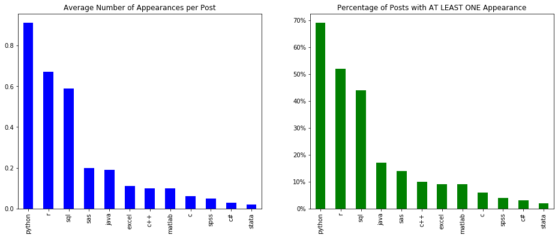

```python
# let's look at some programming languages
lang = ['python', 'r', 'sql', 'sas', 'spss', 'stata', 'matlab', 'excel', 'java', 'c', 'c#', 'c++']
comp_plot(lang)
```

It looks like **Python, R, and SQL** are the most in-demand programming languages to know!

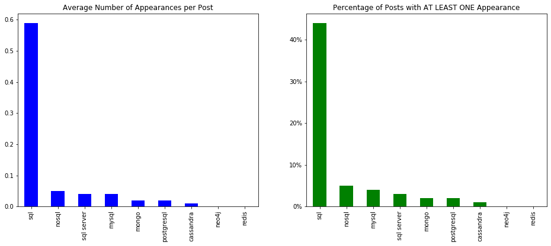

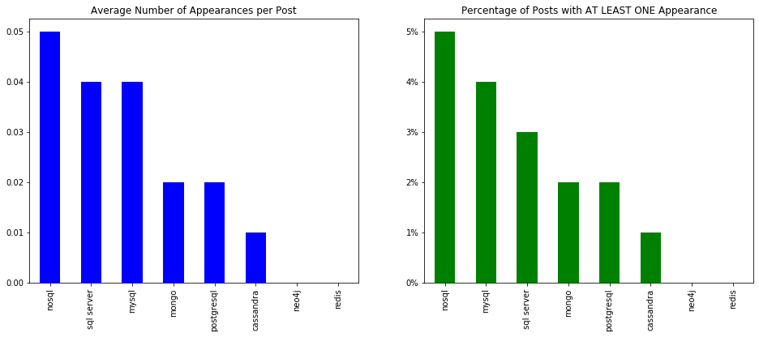

```python
# now lets run the same comparisons on other technologies, specifically sql databases
sql_data = ['sql', 'nosql', 'mysql', 'postgresql', 'sql server', 'mongo', 'redis',
            'cassandra', 'neo4j']
comp_plot(sql_data)

# lets also run it without SQL, better focus on the other values
sql_data.remove('sql')
comp_plot(sql_data)
```

Outside of general **SQL**, it appears there are not a ton of mentions of other database technologies

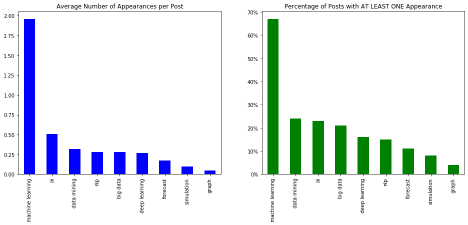

```python
# the buzzword terms
buzzword = ['big data', 'machine learning', 'deep learning', 'ai', 'nlp', 'graph',
            'data mining', 'simulation', 'forecast']
comp_plot(buzzword)
```

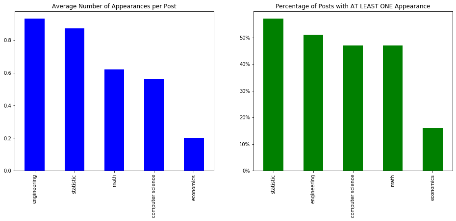

```python
# finally, the degrees
skills = ['statistic', 'math', 'computer science', 'engineering', 'economics']
comp_plot(skills)
```

It looks like a toss-up between **Engineering, Statistics, Math, and Computer Science** when it comes to some of the backgrounds employers are looking for. Good news that they're recruiting from a variety of backgrounds!

```python
# For those of us in the potentially interested in government work, how many mention a
# security clearance?
clear = output.copy()

# encode the presence of 'clearance' in job descriptions
clear['clearance'][clear['clearance'] > 0] = 1

# create the mean and count values for each state
clear = clear.groupby('state')['clearance'].agg(['count', 'mean'])

# limit it to states with more than 10 jobs, and sort by the percentage of postings with a mention
clear = clear[(clear['count'] > 10)& (clear['mean'] > 0)].sort_values('mean', ascending = False)

# round our values, rename the columns, and list
clear['mean'] = round(clear['mean'] * 100, 2)
clear.rename(columns = {'mean':'percentage of jobs mentioning a clearance'})
```

| state | count | percentage of jobs mentioning a clearance |
| --- | --- | --- |
| MD | 130 | 40.77 |
| DC | 144 | 38.19 |
| VA | 309 | 36.25 |
| FL | 44 | 6.82 |
| MO | 15 | 6.67 |
| MA | 134 | 5.22 |
| OH | 42 | 4.76 |
| WA | 127 | 3.94 |
| CO | 34 | 2.94 |
| TX | 119 | 2.52 |
| NC | 52 | 1.92 |
| CA | 402 | 1.49 |
| IL | 73 | 1.37 |

It shouldn't come as much of a surprise, but it looks like a lot of jobs in the DMV (**over 1/3!**) mention a security clearance in their job description. But a majority still dont, plus other states have much fewer mentions.

So now that we know a little more about where these jobs are and what they are looking for, hopefully this can take a little bit of the stress out of the job appliaction process!

And this is just scratching the surface, there is so much more information to glean. We can look at job requirements by specific companies, see if skills are more prevalent in specific regions, or if start ups and other small companies are asking for a different set of skills.

So with the dataset(s) in hand - feel free to keep exploring!